# write_up

#### Advanced Lane Line Finder

These are the libraries utilized during this project, in addition to help myself in the understanding of the typical pipeline steps for image processing, I have created a separate file with all the functions utilized, such functions are called here only to pass the arguments. You can find the functions implementations in "Helper_functions_2.py" in this workspace.

```python
import helper_functions_2 as hf
import numpy as np
import matplotlib.pyplot as plt
import matplotlib.image as mpimg
import cv2
import glob
from moviepy.editor import VideoFileClip
from IPython.display import HTML
%reload_ext autoreload
%autoreload 2
```

#### 1. Image calibration

##### I calibrate the images using the 9x6 chessboard images provided, the output of this function is stored in the variables objpoints and imgpoints

```python
objpoints, imgpoints = hf.calibration()
```

#### 2. Load the test images

##### Once the calibration object points and image points are acquired I am ready to load the test images provided to later use these images and feed the points found to the undistort function

```python
test_images = hf.image_loader()
```

#### 3. Undistort the images

##### With the undistortion coefficients that are returned by the undistort function, I perform the camera calibration, example images are provided

```python
undistorted_ones = []
for each_image in test_images:
    undistorted_one = hf.undistort(each_image, objpoints, imgpoints)
    undistorted_ones.append(undistorted_one)

# I have all the images now in undistorted ones array
```

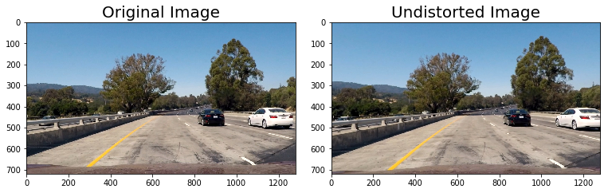

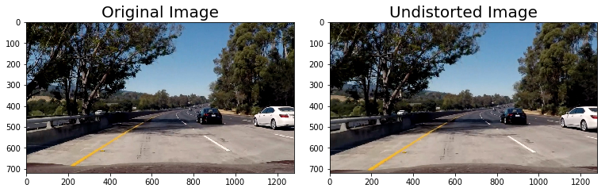

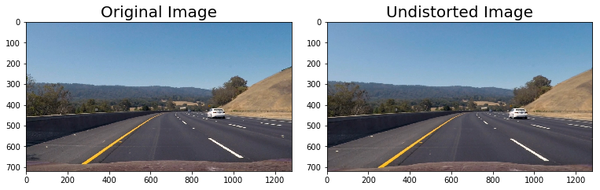

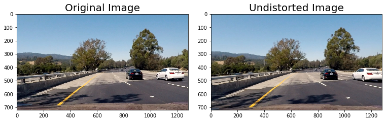

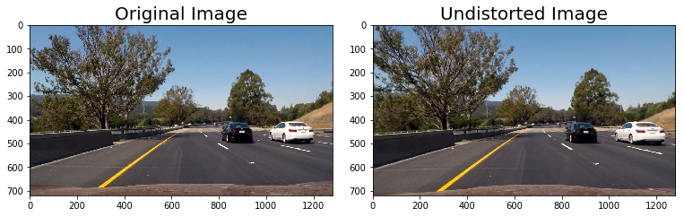

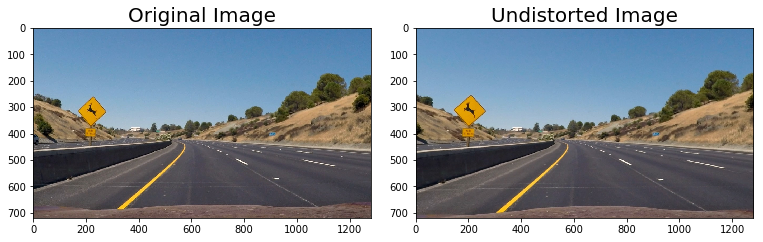

```python
for index, image in enumerate(test_images,0):
        f, (ax1, ax2) = plt.subplots(1, 2, figsize=(10, 9))
        f.tight_layout()
        ax1.imshow(test_images[index])
        ax1.set_title('Original Image', fontsize=20)
        ax2.imshow(undistorted_ones[index])
        ax2.set_title('Undistorted Image', fontsize=20)
        plt.subplots_adjust(left=0., right=1, top=0.9, bottom=0.)
```

#### 4. Image Processing : Color selection, gradients, perspective transform and Polynomial Fit

##### Once I have the undistorted images I feed them into the Pipeline processing function, where the different techniques for color selection, gradient, masking, perspective transform are performed. See images Provided

```python
def pipeline(image):
    h,l,s = hf.hls_selector(image)
    color = hf.color_threshold(s, color_t=(170,255))
    sobely = hf.sobel_y(s, thresh_min=40, thresh_max=255)
    sobelx = hf.sobel_x(s, thresh_min=10, thresh_max=100)
    combined = np.zeros_like(sobelx)
    combined = np.dstack(( sobely, color, sobelx))*255
    warped_image, m_inv = hf.perspective_transform(combined)
    return s, color, sobely, sobelx, combined, warped_image
```

```python
image_combined, image_warped = [], []
#images_dict['Image Transformations'] = []
for each_image in undistorted_ones:
    s, color, sy, sx, c, wi = pipeline(each_image)
    image_combined.append(c)
    image_warped.append(wi)
```

[figure not shown]

[figure not shown]

[figure not shown]

[figure not shown]

[figure not shown]

[figure not shown]

```python
for index, image in enumerate(image_combined,0):
        f, (ax1, ax2) = plt.subplots(1, 2, figsize=(10, 9))
        f.tight_layout()
        ax1.imshow(undistorted_ones[index])
        ax1.set_title('Undistorted', fontsize=20)
        ax2.imshow(image_combined[index])
        ax2.set_title('Combined', fontsize=20)
        plt.subplots_adjust(left=0., right=1, top=0.9, bottom=0.)
```

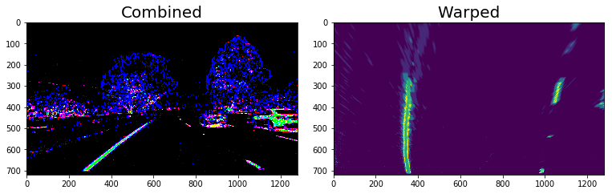

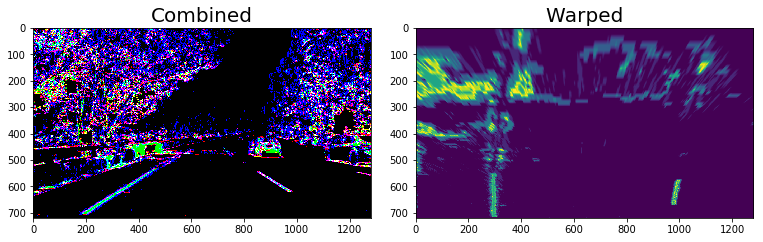

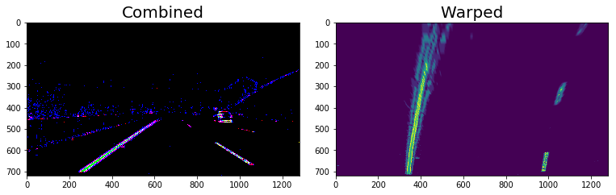

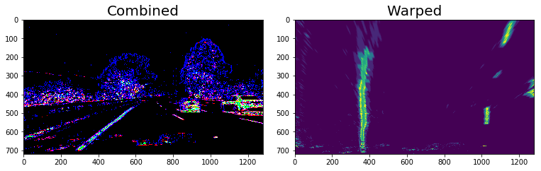

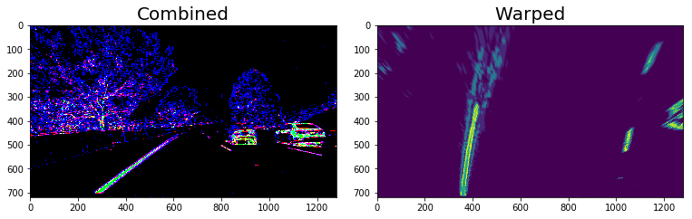

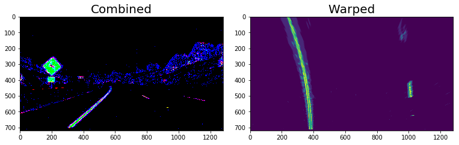

```python
for index, image in enumerate(image_warped,0):
        f, (ax1, ax2) = plt.subplots(1, 2, figsize=(10, 9))
        f.tight_layout()
        ax1.imshow(image_combined[index])
        ax1.set_title('Combined', fontsize=20)
        ax2.imshow(image_warped[index])
        ax2.set_title('Warped', fontsize=20)
        plt.subplots_adjust(left=0., right=1, top=0.9, bottom=0.)
```

#### Curvature measurement

The measurement of the center of the car and curvature was done using the function Curvature Real Measurement written in the helper functions in this working directory, additionally by leveraging the paradigm of Object oriented Programmin, an object Line was created to store the current position and other values that are attributes of the line, by using these the center of the car was found, as coded in the main pipeline using these lines of code:

```python
center_car = image.shape[1] // 2

    l_c = int(right_pos - left_pos)
    offset = (l_c - center_car) * (3.7/700)
```

#### Video Project Link

https://github.com/WilliamGalindezArias/project_2/blob/master/video_test4.mp4

#### Challenges

The changes of light and shadows in the road represent a challenge to the pipeline defined, probably because these ones have an impact in the measurements being taken by the counter of pixels and add noise to the detected lines. A possible way to fix this is implementing a feedback system to control and select what should be the polynomial that should be plotted if the obtained one is above certain threshold